# Día 4: Descomposición de la esperanza de vida en Venezuela

Autor/a

José Manuel Aburto y Ana Cristina Gómez Ugarte Valerio

Fecha de publicación

2026

En esta práctica aplicaremos el método integral lineal de Horiuchi et al. (2008) para descomponer el cambio en la esperanza de vida de los hombres de Venezuela entre 1996 y 2013.

Trabajaremos en dos etapas:

1. Descomposición por edad.
2. Extensión por edad y causa de muerte.

El archivo `descomposicion-venezuela-data.RData` contiene tablas de vida y tasas de mortalidad por edad y causa para 1996 y 2013. Las diez causas son exhaustivas y mutuamente excluyentes; para el ejercicio suponemos que actúan de manera independiente.

## 1. Preparación

```r
library(DemoDecomp)
library(ggplot2)
library(tidyr)

load("descomposicion-venezuela-data.RData")
source("funciones-descomposicion-venezuela.R")
```

Exploremos los objetos disponibles.

```r
str(age.specific.mx)
```

```
Classes 'data.table' and 'data.frame':  38 obs. of  4 variables:
 $ sex : int  1 1 1 1 1 1 1 1 1 1 ...
 $ year: int  1996 1996 1996 1996 1996 1996 1996 1996 1996 1996 ...
 $ age : int  0 1 5 10 15 20 25 30 35 40 ...
 $ mx  : num  0.024517 0.001509 0.000488 0.000541 0.001935 ...
 - attr(*, ".internal.selfref")=<externalptr>
```

```r
str(cause.age.specific.mx)
```

```
Classes 'data.table' and 'data.frame':  38 obs. of  13 variables:
 $ 1   : num  1.11e-04 2.38e-05 1.72e-05 1.40e-05 6.24e-05 ...
 $ 2   : num  3.95e-05 8.18e-05 4.25e-05 2.29e-05 5.88e-05 ...
 $ 3   : num  1.08e-05 2.85e-06 7.46e-07 1.02e-06 9.44e-06 ...
 $ 4   : num  2.69e-04 4.95e-05 7.31e-05 2.90e-04 1.04e-03 ...
 $ 5   : num  1.18e-04 9.89e-05 1.21e-04 1.01e-04 4.26e-04 ...
 $ 6   : num  1.17e-02 0.00 7.46e-07 0.00 0.00 ...
 $ 7   : num  1.81e-03 2.12e-04 2.24e-05 1.14e-05 3.48e-05 ...
 $ 8   : num  4.59e-03 3.90e-04 2.46e-05 9.15e-06 5.37e-05 ...
 $ 9   : num  2.15e-04 2.57e-05 8.21e-06 5.34e-06 2.98e-05 ...
 $ 10  : num  5.64e-03 6.24e-04 1.78e-04 8.56e-05 2.21e-04 ...
 $ sex : num  1 1 1 1 1 1 1 1 1 1 ...
 $ year: int  1996 1996 1996 1996 1996 1996 1996 1996 1996 1996 ...
 $ age : int  0 1 5 10 15 20 25 30 35 40 ...
 - attr(*, ".internal.selfref")=<externalptr>
```

## 2. Descomposición del cambio en la esperanza de vida por edad

Primero necesitamos dos vectores de tasas de mortalidad por edad: uno para 1996 y otro para 2013.

```r
mx_1996 <- age.specific.mx[
  age.specific.mx$year == 1996,
]$mx

mx_2013 <- age.specific.mx[
  age.specific.mx$year == 2013,
]$mx
```

La función `e0.frommx()` calcula la esperanza de vida al nacer a partir de un vector de tasas de mortalidad. El paquete **DemoDecomp** contiene la función `horiuchi()`, que implementa la descomposición integral lineal.

```r
e0.frommx
```

```
function (nmx = mx, sex = 1, age = c(0, 1, seq(5, 85, 5)), nax = NULL)
{
    n <- c(diff(age), 999)
    if (is.null(nax)) {
        nax <- 0.5 * n
        if (n[2] == 4) {
            if (sex == 1) {
                if (nmx[1] >= 0.107) {
                  nax[1] <- 0.33
                  nax[2] <- 1.352
                }
                else {
                  nax[1] <- 0.045 + 2.684 * nmx[1]
                  nax[2] <- 1.651 - 2.816 * nmx[1]
                }
            }
            if (sex == 2) {
                if (nmx[1] >= 0.107) {
                  nax[1] <- 0.35
                  nax[2] <- 1.361
                }
                else {
                  nax[1] <- 0.053 + 2.8 * nmx[1]
                  nax[2] <- 1.522 - 1.518 * nmx[1]
                }
            }
        }
    }
    nqx <- (n * nmx)/(1 + (n - nax) * nmx)
    nqx <- c(nqx[-(length(nqx))], 1)
    nqx[nqx > 1] <- 1
    npx <- 1 - nqx
    lx <- cumprod(c(1, npx))
    ndx <- -diff(lx)
    lxpn <- lx[-1]
    nLxpn <- n * lxpn + ndx * nax
    nLx <- c(nLxpn[-length(nLxpn)], lxpn[length(lxpn) - 1]/nmx[length(nmx)])
    Tx <- rev(cumsum(rev(nLx)))
    lx <- lx[1:length(age)]
    ex <- Tx/lx
    e0 <- ex[1]
    return(e0)
}
```

```r
horiuchi
```

```
function (func, pars1, pars2, N, ...)
{
    d <- pars2 - pars1
    n <- length(pars1)
    delta <- d/N
    grad <- matrix(rep(0.5:(N - 0.5)/N, n), byrow = TRUE, ncol = N)
    x <- pars1 + d * grad
    cc <- matrix(0, nrow = n, ncol = N)
    rownames(x) <- names(pars1)
    for (j in 1:N) {
        DD <- diag(delta/2)
        for (i in 1:n) {
            cc[i, j] <- func((x[, j] + DD[, i]), ...) - func((x[,
                j] - DD[, i]), ...)
        }
    }
    out <- rowSums(cc)
    names(out) <- names(pars1)
    out
}
<bytecode: 0x1466eaf58>
<environment: namespace:DemoDecomp>
```

Aplicamos ahora la descomposición. El resultado es un vector con la contribución de cada grupo de edad al cambio de la esperanza de vida.

```r
resultados_edad <- horiuchi(
  func = e0.frommx,
  pars1 = mx_1996,
  pars2 = mx_2013,
  N = 100
)

resultados_edad
```

```
 [1]  0.548578198  0.238453633  0.055370532  0.036289114 -0.308392214
 [6] -0.511607774 -0.280022896 -0.173391001 -0.060898629  0.024443227
[11]  0.047212050  0.006173258  0.090497818  0.181146595  0.376724271
[16]  0.351641464  0.316616151  0.416496331  0.296039894
```

Comprobamos la consistencia entre la diferencia observada y la suma de las contribuciones.

```r
diferencia_observada <- e0.frommx(mx_2013) - e0.frommx(mx_1996)
diferencia_descompuesta <- sum(resultados_edad)
error_numerico <- diferencia_descompuesta - diferencia_observada

c(
  diferencia_observada = diferencia_observada,
  diferencia_descompuesta = diferencia_descompuesta,
  error_numerico = error_numerico
)
```

```
   diferencia_observada diferencia_descompuesta          error_numerico
           1.651372e+00            1.651370e+00           -1.903336e-06
```

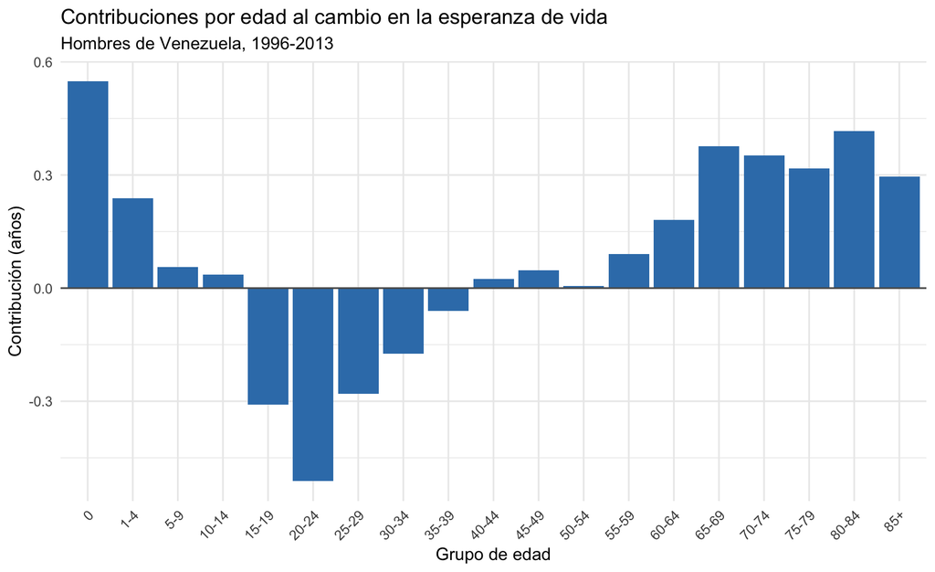

```r
datos_edad <- data.frame(
  edad = factor(age_names, levels = age_names),
  contribucion = resultados_edad
)

ggplot(datos_edad, aes(x = edad, y = contribucion)) +
  geom_col(fill = "#377EB8") +
  geom_hline(yintercept = 0, colour = "grey35") +
  labs(
    title = "Contribuciones por edad al cambio en la esperanza de vida",
    subtitle = "Hombres de Venezuela, 1996-2013",
    x = "Grupo de edad",
    y = "Contribución (años)"
  ) +
  theme_minimal(base_size = 12) +
  theme(axis.text.x = element_text(angle = 45, hjust = 1))
```

**Preguntas:**

- ¿Qué edades explican la mayor parte del cambio en la esperanza de vida?
- ¿Hay edades con contribuciones negativas?
- ¿Qué indica el tamaño del error numérico?

## 3. Extensión por edad y causa de muerte

Construimos dos matrices de tasas. Las filas representan grupos de edad y las columnas representan causas de muerte.

```r
cod_1996 <- as.matrix(
  cause.age.specific.mx[
    cause.age.specific.mx$year == 1996,
    1:10
  ]
)

cod_2013 <- as.matrix(
  cause.age.specific.mx[
    cause.age.specific.mx$year == 2013,
    1:10
  ]
)
```

La función auxiliar siguiente transforma el vector que recibe `horiuchi()` en una matriz de tasas por edad y causa, suma las causas y calcula la esperanza de vida.

```r
e0.frommxc <- function(mxc_vector, sex = 1) {
  dim(mxc_vector) <- c(19, length(mxc_vector) / 19)
  mx <- rowSums(mxc_vector)
  e0.frommx(mx, sex)
}
```

```r
resultados_causa <- horiuchi(
  func = e0.frommxc,
  pars1 = c(cod_1996),
  pars2 = c(cod_2013),
  N = 100
)

dim(resultados_causa) <- dim(cod_1996)
resultados_causa
```

```
               [,1]          [,2]          [,3]          [,4]          [,5]
 [1,]  4.217918e-03  0.0008808138  0.0007420892  0.0098113755  0.0019523739
 [2,]  4.289051e-03  0.0076390274  0.0005336350 -0.0008564005  0.0127357261
 [3,]  4.003514e-03  0.0022921591 -0.0001112929 -0.0039980229  0.0172048394
 [4,]  2.960660e-03  0.0038052662  0.0000303520  0.0002222279  0.0086199834
 [5,]  4.590370e-03 -0.0001051925  0.0012162349 -0.3015918057 -0.0398756696
 [6,] -8.664123e-04  0.0016863482 -0.0004726468 -0.4632923831 -0.0690744422
 [7,]  2.747242e-03  0.0010329431 -0.0020252406 -0.2829054183 -0.0317993009
 [8,] -5.270914e-05 -0.0001320688 -0.0087313732 -0.1592305687 -0.0071370867
 [9,]  1.055335e-03  0.0099783410 -0.0045924290 -0.0765550446  0.0003143796
[10,]  3.817584e-02  0.0023606488 -0.0055942042 -0.0398057830  0.0146184530
[11,]  1.180050e-02  0.0064653722  0.0040697681 -0.0225122431  0.0471929044
[12,]  3.009605e-02 -0.0025946044 -0.0144696754 -0.0287881274  0.0120136868
[13,]  8.301947e-02 -0.0027903944 -0.0239196694 -0.0067918603  0.0175178138
[14,]  1.171585e-01  0.0286319222 -0.0313412899 -0.0090071645  0.0187071780
```

[output cut: 25 more lines]

Volvemos a comprobar la consistencia de la descomposición.

```r
diferencia_observada_causa <- e0.frommxc(cod_2013) -
  e0.frommxc(cod_1996)
diferencia_descompuesta_causa <- sum(resultados_causa)
error_numerico_causa <- diferencia_descompuesta_causa -
  diferencia_observada_causa

c(
  diferencia_observada = diferencia_observada_causa,
  diferencia_descompuesta = diferencia_descompuesta_causa,
  error_numerico = error_numerico_causa
)
```

```
   diferencia_observada diferencia_descompuesta          error_numerico
           1.651372e+00            1.651370e+00           -2.389003e-06
```

Preparamos los resultados para representarlos.

```r
datos_causa <- data.frame(resultados_causa)
colnames(datos_causa) <- cause_names
datos_causa$edad <- factor(age_names, levels = age_names)

datos_causa <- pivot_longer(
  datos_causa,
  cols = -edad,
  names_to = "causa",
  values_to = "contribucion"
)
```

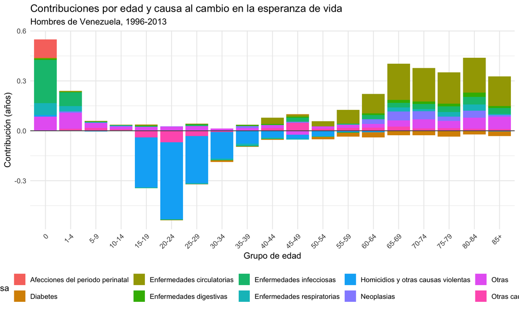

```r
ggplot(
  datos_causa,
  aes(x = edad, y = contribucion, fill = causa)
) +
  geom_col() +
  geom_hline(yintercept = 0, colour = "grey35") +
  labs(
    title = "Contribuciones por edad y causa al cambio en la esperanza de vida",
    subtitle = "Hombres de Venezuela, 1996-2013",
    x = "Grupo de edad",
    y = "Contribución (años)",
    fill = "Causa"
  ) +
  theme_minimal(base_size = 12) +
  theme(
    axis.text.x = element_text(angle = 45, hjust = 1),
    legend.position = "bottom"
  )
```

**Preguntas:**

- ¿Qué combinación de edad y causa explica la mayor contribución negativa?
- ¿Qué papel tienen los homicidios y otras causas violentas?
- ¿Cómo cambia la interpretación al pasar de una descomposición únicamente por edad a otra por edad y causa?

## 4. Extensión: desviación estándar de la edad a la muerte

Podemos repetir el análisis para la desviación estándar de la distribución de las edades a la muerte.

```r
resultados_sd <- horiuchi(
  func = sdfrommxc,
  pars1 = c(cod_1996),
  pars2 = c(cod_2013),
  N = 100
)

dim(resultados_sd) <- dim(cod_1996)

diferencia_observada_sd <- sdfrommxc(cod_2013) -
  sdfrommxc(cod_1996)
diferencia_descompuesta_sd <- sum(resultados_sd)
error_numerico_sd <- diferencia_descompuesta_sd -
  diferencia_observada_sd

c(
  diferencia_observada = diferencia_observada_sd,
  diferencia_descompuesta = diferencia_descompuesta_sd,
  error_numerico = error_numerico_sd
)
```

```
   diferencia_observada diferencia_descompuesta          error_numerico
           9.518884e-01            9.518872e-01           -1.249780e-06
```

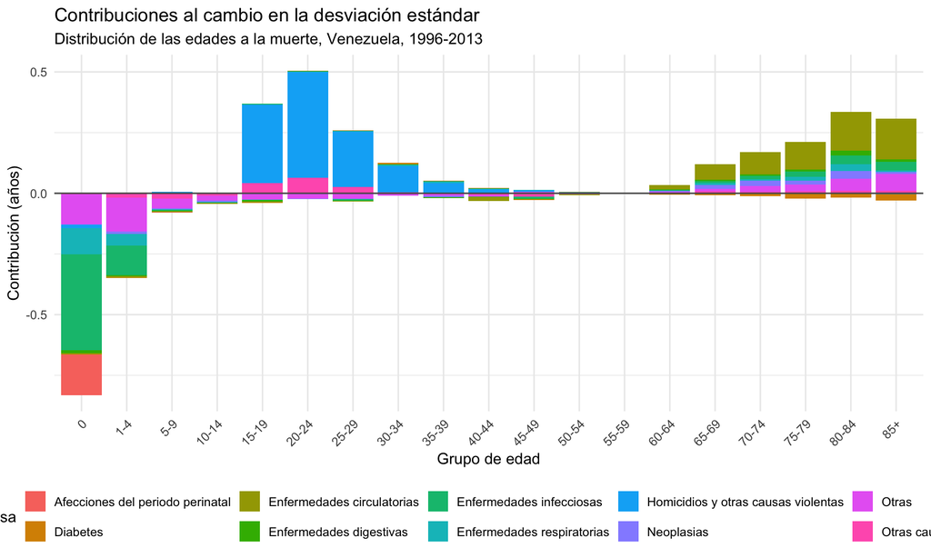

```r
datos_sd <- data.frame(resultados_sd)
colnames(datos_sd) <- cause_names
datos_sd$edad <- factor(age_names, levels = age_names)

datos_sd <- pivot_longer(
  datos_sd,
  cols = -edad,
  names_to = "causa",
  values_to = "contribucion"
)

ggplot(
  datos_sd,
  aes(x = edad, y = contribucion, fill = causa)
) +
  geom_col() +
  geom_hline(yintercept = 0, colour = "grey35") +
  labs(
    title = "Contribuciones al cambio en la desviación estándar",
    subtitle = "Distribución de las edades a la muerte, Venezuela, 1996-2013",
    x = "Grupo de edad",
    y = "Contribución (años)",
    fill = "Causa"
  ) +
  theme_minimal(base_size = 12) +
  theme(
    axis.text.x = element_text(angle = 45, hjust = 1),
    legend.position = "bottom"
  )
```

**Pregunta final:** ¿qué información adicional aporta la variación de la edad a la muerte frente a la esperanza de vida?